# Checkpoint 1

Reminder:

- You are being evaluated for compeletion and effort in this checkpoint.
- Avoid manual labor / hard coding as much as possible, everything we've taught you so far are meant to simplify and automate your process.

We will be working with the same `states_edu.csv` that you should already be familiar with from the tutorial.

We investigated Grade 8 reading score in the tutorial. For this checkpoint, you are asked to investigate another test. Here's an overview:

- Choose a specific response variable to focus on

> Grade 4 Math, Grade 4 Reading, Grade 8 Math
- Pick or create features to use

> Will all the features be useful in predicting test score? Are some more important than others? Should you standardize, bin, or scale the data?
- Explore the data as it relates to that test

> Create at least 2 visualizations (graphs), each with a caption describing the graph and what it tells us about the data
- Create training and testing data

> Do you want to train on all the data? Only data from the last 10 years? Only Michigan data?
- Train a ML model to predict outcome

> Define what you want to predict, and pick a model in sklearn to use (see sklearn [regressors](https://scikit-learn.org/stable/modules/linear_model.html).
- Summarize your findings

> Write a 1 paragraph summary of what you did and make a recommendation about if and how student performance can be predicted

Include comments throughout your code! Every cleanup and preprocessing task should be documented.

Of course, if you're finding this assignment interesting (and we really hope you do!), you are welcome to do more than the requirements! For example, you may want to see if expenditure affects 4th graders more than 8th graders. Maybe you want to look into the extended version of this dataset and see how factors like sex and race are involved. You can include all your work in this notebook when you turn it in -- just always make sure you explain what you did and interpret your results. Good luck!

## Data Cleanup

Import `numpy`, `pandas`, and `matplotlib`.

(Feel free to import other libraries!)

```python
import numpy as np
import pandas as pd
import matplotlib.pyplot as plt
pd.options.mode.chained_assignment = None
```

Load in the "states_edu.csv" dataset and take a look at the head of the data

```python
df= pd.read_csv("/home/ezhan/MDST_checkpoints/states_edu.csv")
df.head()
```

|  | PRIMARY_KEY | STATE | YEAR | ENROLL | TOTAL_REVENUE | FEDERAL_REVENUE | STATE_REVENUE | LOCAL_REVENUE | TOTAL_EXPENDITURE | INSTRUCTION_EXPENDITURE | ... | GRADES_4_G | GRADES_8_G | GRADES_12_G | GRADES_1_8_G | GRADES_9_12_G | GRADES_ALL_G | AVG_MATH_4_SCORE | AVG_MATH_8_SCORE | AVG_READING_4_SCORE | AVG_READING_8_SCORE |
| --- | --- | --- | --- | --- | --- | --- | --- | --- | --- | --- | --- | --- | --- | --- | --- | --- | --- | --- | --- | --- | --- |
| 0 | 1992_ALABAMA | ALABAMA | 1992 | NaN | 2678885.0 | 304177.0 | 1659028.0 | 715680.0 | 2653798.0 | 1481703.0 | ... | 57948.0 | 58025.0 | 41167.0 | NaN | NaN | 731634.0 | 208.0 | 252.0 | 207.0 | NaN |
| 1 | 1992_ALASKA | ALASKA | 1992 | NaN | 1049591.0 | 106780.0 | 720711.0 | 222100.0 | 972488.0 | 498362.0 | ... | 9748.0 | 8789.0 | 6714.0 | NaN | NaN | 122487.0 | NaN | NaN | NaN | NaN |
| 2 | 1992_ARIZONA | ARIZONA | 1992 | NaN | 3258079.0 | 297888.0 | 1369815.0 | 1590376.0 | 3401580.0 | 1435908.0 | ... | 55433.0 | 49081.0 | 37410.0 | NaN | NaN | 673477.0 | 215.0 | 265.0 | 209.0 | NaN |
| 3 | 1992_ARKANSAS | ARKANSAS | 1992 | NaN | 1711959.0 | 178571.0 | 958785.0 | 574603.0 | 1743022.0 | 964323.0 | ... | 34632.0 | 36011.0 | 27651.0 | NaN | NaN | 441490.0 | 210.0 | 256.0 | 211.0 | NaN |
| 4 | 1992_CALIFORNIA | CALIFORNIA | 1992 | NaN | 26260025.0 | 2072470.0 | 16546514.0 | 7641041.0 | 27138832.0 | 14358922.0 | ... | 418418.0 | 363296.0 | 270675.0 | NaN | NaN | 5254844.0 | 208.0 | 261.0 | 202.0 | NaN |

5 rows × 25 columns

You should always familiarize yourself with what each column in the dataframe represents. Read about the states_edu dataset here: https://www.kaggle.com/noriuk/us-education-datasets-unification-project

Use this space to rename columns, deal with missing data, etc. *(optional)*

```python
df.isna().sum()
```

```
PRIMARY_KEY                        0
STATE                              0
YEAR                               0
ENROLL                           491
TOTAL_REVENUE                    440
FEDERAL_REVENUE                  440
STATE_REVENUE                    440
LOCAL_REVENUE                    440
TOTAL_EXPENDITURE                440
INSTRUCTION_EXPENDITURE          440
SUPPORT_SERVICES_EXPENDITURE     440
OTHER_EXPENDITURE                491
CAPITAL_OUTLAY_EXPENDITURE       440
GRADES_PK_G                      173
GRADES_KG_G                       83
GRADES_4_G                        83
GRADES_8_G                        83
GRADES_12_G                       83
GRADES_1_8_G                     695
GRADES_9_12_G                    644
GRADES_ALL_G                      83
AVG_MATH_4_SCORE                1150
AVG_MATH_8_SCORE                1113
AVG_READING_4_SCORE             1065
AVG_READING_8_SCORE             1153
dtype: int64
```

```python
df.dropna()
```

|  | PRIMARY_KEY | STATE | YEAR | ENROLL | TOTAL_REVENUE | FEDERAL_REVENUE | STATE_REVENUE | LOCAL_REVENUE | TOTAL_EXPENDITURE | INSTRUCTION_EXPENDITURE | ... | GRADES_4_G | GRADES_8_G | GRADES_12_G | GRADES_1_8_G | GRADES_9_12_G | GRADES_ALL_G | AVG_MATH_4_SCORE | AVG_MATH_8_SCORE | AVG_READING_4_SCORE | AVG_READING_8_SCORE |
| --- | --- | --- | --- | --- | --- | --- | --- | --- | --- | --- | --- | --- | --- | --- | --- | --- | --- | --- | --- | --- | --- |
| 561 | 2003_ALABAMA | ALABAMA | 2003 | 727900.0 | 5196054.0 | 567704.0 | 2966981.0 | 1661369.0 | 5298932.0 | 2817111.0 | ... | 57323.0 | 59663.0 | 42005.0 | 466920.0 | 205907.0 | 731220.0 | 223.0 | 262.0 | 207.0 | 253.0 |
| 562 | 2003_ALASKA | ALASKA | 2003 | 133303.0 | 1425948.0 | 259423.0 | 813371.0 | 353154.0 | 1610289.0 | 763525.0 | ... | 10115.0 | 11140.0 | 8651.0 | 82337.0 | 40238.0 | 133933.0 | 233.0 | 279.0 | 212.0 | 256.0 |
| 563 | 2003_ARIZONA | ARIZONA | 2003 | 875111.0 | 6529894.0 | 740579.0 | 2912629.0 | 2876686.0 | 6210287.0 | 2810907.0 | ... | 76207.0 | 76376.0 | 68815.0 | 613442.0 | 307272.0 | 1012068.0 | 229.0 | 271.0 | 209.0 | 255.0 |
| 564 | 2003_ARKANSAS | ARKANSAS | 2003 | 450158.0 | 3241275.0 | 379947.0 | 2394336.0 | 466992.0 | 3242799.0 | 1768713.0 | ... | 34070.0 | 37004.0 | 28840.0 | 281834.0 | 132712.0 | 454523.0 | 229.0 | 266.0 | 214.0 | 258.0 |
| 565 | 2003_CALIFORNIA | CALIFORNIA | 2003 | 6226552.0 | 59815855.0 | 5795655.0 | 33617766.0 | 20402434.0 | 59749885.0 | 29561563.0 | ... | 493415.0 | 500143.0 | 395194.0 | 3929869.0 | 1854518.0 | 6413867.0 | 227.0 | 267.0 | 206.0 | 251.0 |
| ... | ... | ... | ... | ... | ... | ... | ... | ... | ... | ... | ... | ... | ... | ... | ... | ... | ... | ... | ... | ... | ... |
| 1219 | 2015_VIRGINIA | VIRGINIA | 2015 | 1279867.0 | 15857524.0 | 1012205.0 | 6240349.0 | 8604970.0 | 16113212.0 | 8755896.0 | ... | 96851.0 | 95221.0 | 90391.0 | 772414.0 | 386781.0 | 1283590.0 | 247.0 | 288.0 | 229.0 | 267.0 |
| 1220 | 2015_WASHINGTON | WASHINGTON | 2015 | 1072359.0 | 13709442.0 | 1036422.0 | 8293812.0 | 4379208.0 | 13630138.0 | 6508964.0 | ... | 82404.0 | 79483.0 | 89258.0 | 656797.0 | 336808.0 | 1087030.0 | 245.0 | 287.0 | 226.0 | 267.0 |
| 1221 | 2015_WEST_VIRGINIA | WEST_VIRGINIA | 2015 | 279565.0 | 3478401.0 | 362959.0 | 1979466.0 | 1135976.0 | 3466981.0 | 1819903.0 | ... | 19814.0 | 20426.0 | 18432.0 | 162070.0 | 80142.0 | 277452.0 | 235.0 | 271.0 | 216.0 | 260.0 |
| 1222 | 2015_WISCONSIN | WISCONSIN | 2015 | 861813.0 | 11637376.0 | 814385.0 | 5869265.0 | 4953726.0 | 11553677.0 | 5723474.0 | ... | 60999.0 | 61084.0 | 66253.0 | 489919.0 | 263896.0 | 867800.0 | 243.0 | 289.0 | 223.0 | 270.0 |
| 1223 | 2015_WYOMING | WYOMING | 2015 | 93867.0 | 1962874.0 | 120290.0 | 1116917.0 | 725667.0 | 1942406.0 | 895910.0 | ... | 7551.0 | 6902.0 | 6299.0 | 59453.0 | 26914.0 | 94717.0 | 247.0 | 287.0 | 228.0 | 269.0 |

355 rows × 25 columns

## Exploratory Data Analysis (EDA)

Chosen Outcome Variable for Test: *Avg_Math_8_Score*

How many years of data are logged in our dataset?

```python
df["YEAR"].nunique()
```

```
33
```

Let's compare Michigan to Ohio. Which state has the higher average outcome score across all years?

```python
michigan_df = df[df['STATE'] == 'MICHIGAN']


michigan_df['AVG_MATH_8_SCORE'].mean()
```

```
276.1666666666667
```

```python
ohio_df = df[df['STATE'] == 'OHIO']
ohio_df['AVG_MATH_8_SCORE'].mean()
```

```
282.25
```

Find the average for your outcome score across all states in 2019

```python
df_2019 = df[df['YEAR'] == 2019]
df_2019['AVG_MATH_8_SCORE'].mean()
```

```
281.2641509433962
```

Find the maximum outcome score for every state.

Refer to the `Grouping and Aggregating` section in Tutorial 0 if you are stuck.

```python
df.groupby('STATE')['AVG_MATH_8_SCORE'].max()
```

```
STATE
ALABAMA                 269.0
ALASKA                  283.0
ARIZONA                 283.0
ARKANSAS                279.0
CALIFORNIA              277.0
COLORADO                292.0
CONNECTICUT             289.0
DELAWARE                284.0
DISTRICT_OF_COLUMBIA    269.0
DODEA                   293.0
FLORIDA                 281.0
GEORGIA                 281.0
HAWAII                  281.0
IDAHO                   287.0
ILLINOIS                285.0
INDIANA                 288.0
IOWA                    286.0
KANSAS                  290.0
KENTUCKY                282.0
LOUISIANA               273.0
MAINE                   289.0
MARYLAND                288.0
MASSACHUSETTS           301.0
MICHIGAN                280.0
MINNESOTA               295.0
MISSISSIPPI             274.0
MISSOURI                286.0
MONTANA                 293.0
NATIONAL                285.0
NEBRASKA                288.0
NEVADA                  278.0
NEW_HAMPSHIRE           296.0
NEW_JERSEY              296.0
NEW_MEXICO              274.0
NEW_YORK                283.0
NORTH_CAROLINA          286.0
NORTH_DAKOTA            293.0
OHIO                    290.0
OKLAHOMA                279.0
OREGON                  285.0
PENNSYLVANIA            290.0
RHODE_ISLAND            284.0
SOUTH_CAROLINA          282.0
SOUTH_DAKOTA            291.0
TENNESSEE               280.0
TEXAS                   290.0
UTAH                    287.0
VERMONT                 295.0
VIRGINIA                290.0
WASHINGTON              290.0
WEST_VIRGINIA           274.0
WISCONSIN               289.0
WYOMING                 289.0
Name: AVG_MATH_8_SCORE, dtype: float64
```

## Feature Engineering

After exploring the data, you can choose to modify features that you would use to predict the performance of the students on your chosen response variable.

You can also create your own features. For example, perhaps you figured that maybe a state's expenditure per student may affect their overall academic performance so you create a expenditure_per_student feature.

Use this space to modify or create features.

```python
df['TOTAL_EXPENDITURE_PER_8'] = df['TOTAL_EXPENDITURE'] / df['GRADES_8_G']
df.head
```

[output not shown]

[output cut: 51 more lines]

```python
df["TOTAL_FED_REVENUE_PER_8"] = df["FEDERAL_REVENUE"] / df["GRADES_8_G"]
```

## Visualization

Investigate the relationship between your chosen response variable and at least two predictors using visualizations. Write down your observations.

**Visualization 1**

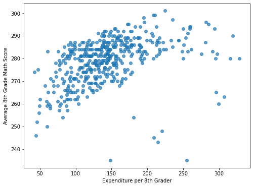

```python
plt.figure(figsize=(8, 6))
plt.scatter(df["TOTAL_EXPENDITURE_PER_8"], df["AVG_MATH_8_SCORE"], alpha=0.7)
plt.xlabel('Expenditure per 8th Grader')
plt.ylabel('Average 8th Grade Math Score')
```

**Visualization 2**

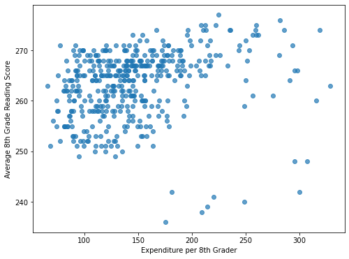

```python
plt.figure(figsize=(8, 6))
plt.scatter(df["TOTAL_EXPENDITURE_PER_8"], df["AVG_READING_8_SCORE"], alpha=0.7)
plt.xlabel('Expenditure per 8th Grader')
plt.ylabel('Average 8th Grade Reading Score')
```

Based on my plot, it seems that there are some correlations with expenditures per 8th grader and their English and Math Levels as we observe, especially in the case of the Math Score, that the higher the expenditure per student, the higher the Math score.

## Data Creation

*Use this space to create train/test data*

```python
from sklearn.model_selection import train_test_split
```

```python
X = df[['GRADES_8_G','TOTAL_EXPENDITURE_PER_8','TOTAL_FED_REVENUE_PER_8']].dropna()
y = df.loc[X.index]['AVG_MATH_8_SCORE']
y.fillna(y.median(), inplace=True)
```

```python
X_train, X_test, y_train, y_test = train_test_split(
      X, y, test_size= 0.3, random_state=42)
```

## Prediction

ML Models [Resource](https://medium.com/@vijaya.beeravalli/comparison-of-machine-learning-classification-models-for-credit-card-default-data-c3cf805c9a5a)

```python
from sklearn.linear_model import LinearRegression
```

```python
model = LinearRegression()
```

```python
model.fit(X_train, y_train)
```

```
LinearRegression()
```

```python
y_pred = model.predict(X_test)
```

## Evaluation

Choose some metrics to evaluate the performance of your model, some of them are mentioned in the tutorial.

```python
model.score(X_test, y_test)
```

```
0.06733117537710487
```

```python
np.mean(model.predict(X_test)-y_test)
```

```
-0.48811914368564163
```

We have copied over the graphs that visualize the model's performance on the training and testing set.

Change `col_name` and modify the call to `plt.ylabel()` to isolate how a single predictor affects the model.

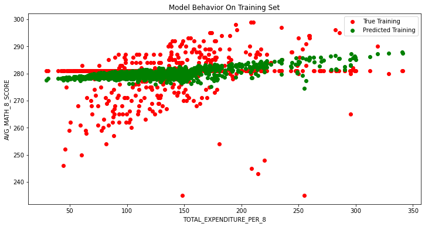

```python
col_name = 'TOTAL_EXPENDITURE_PER_8'

f = plt.figure(figsize=(12,6))
plt.scatter(X_train[col_name], y_train, color = "red")
plt.scatter(X_train[col_name], model.predict(X_train), color = "green")

plt.legend(['True Training','Predicted Training'])
plt.xlabel(col_name)
plt.ylabel('AVG_MATH_8_SCORE')
plt.title("Model Behavior On Training Set")
```

[figure not shown]

```python
col_name = 'TOTAL_FED_REVENUE_PER_8'

f = plt.figure(figsize=(12,6))
plt.scatter(X_test[col_name], y_test, color = "blue")
plt.scatter(X_test[col_name], model.predict(X_test), color = "black")

plt.legend(['True testing','Predicted testing'])
plt.xlabel(col_name)
plt.ylabel('AVG_READING_8_SCORE')
plt.title("Model Behavior on Testing Set")
```

## Summary

I am trying to predict the average 8th graders math score by using the total expenditures per student and the federal revenue per student. From the graph, it seems that there are some positive correlation between total expenditure per student and average 8th graders math score. However, the ML model fails to produce the linear model. Whereas the other two variables, the Total Federal Revenue per 8th graders and the Avergae math scores yields little linear relationships. The matrices used, both the R^2 value and the mean error, yields a far greater error. Therefore, I have concluded that the expenditures per students, whethere it is total expenditures or federal revenue, are not good predictors for prediciting student's average math scores. Other measures, such as a combination of local and federal revenues and expenditures, such as the ratio of Federal Revenue in Total Expenditures, could be used in the future for better predictors.